# Does the stp1 mutant behave like a kinase mutant?

Bio253 HS2026 · Topic C · group mval · final report behind the A0 poster

Authors

Din Vuckic

Mete Kabranlar

Published

November 22, 2026

**How to read this report**

Every number comes from a script in `C_mutant_validation_DinMete/scripts/` (Steps 1–12 of our workflow); each results folder has a `figure_guide_mval.md` that says what each figure compares. Fold changes are **log2, A − B**: `stp_vs_anc_at_TSB = −5.4` means **higher in anc**, lower in stp.

# 1. Question and hypotheses

Stk1 (PknB, kinase) and Stp1 (phosphatase) are encoded in one *stp1–stk1* transcription unit. The `stp` strain carries a transposon in *stp1* (NE1919, codon 189 of 247) upstream of *stk1*, so it may also lack Stk1 (a polar effect).

- **H1** `stp` has reduced Stp1 **and** Stk1; `stk` has reduced Stk1.
- **H2** Some protein responses to *P. aeruginosa* spent medium (PASN) differ from the parent.
- **H3** Part of the `stp` pattern resembles `stk` (shared reduced-kinase component).

# 2. Design and data

*S. aureus* JE2 (`anc`), NE217 *stk1*::Tn (`stk`), NE1919 *stp1*::Tn (`stp`); TSB or ~15 h in 70 % TSB + 30 % cell-free, sterile-filtered PAO1 spent medium (`SN`, “PASN”: only secreted molecules plus partial nutrient depletion; never living *P. aeruginosa*). n = 3 per group. Primary analysis: 18 samples (TSB, SN); all 27 (incl. SNpulse) inform the variance. Total proteome: 2232 JE2 proteins; phosphoproteome searched twice (STY, STYH).

# 3. Methods

| step | what | rule |
| --- | --- | --- |
| model | limma, `~ 0 + group` (9 means), every contrast written as A − B | no reference level can flip a sign |
| hit | `treat()` (McCarthy & Smyth 2009) H0: \|log2FC\| ≤ 1; **BH-FDR < 0.05** within contrast | fixed 12 Nov, before results; no post-hoc fold-change filter |
| eligibility | tested only with ≥ 2 of 3 observed values in every group of the contrast | missing = not detected, never 0; no imputation |
| interaction | (mutant TSB − SN) − (anc TSB − SN) | > 0: SN response lower in the mutant |
| H3 similarity | correlation of `stp` and `stk` effects, corrected for the shared `anc` noise | method of moments, bootstrap CI |
| phospho | ≥ 2 of 3 per group, median per-sample localisation ≥ 0.75 (Olsen et al. 2006), S/T/Y; own BH family | site − protein in the same contrast, descriptive |
| pathways | rank test + limma `cameraPR` (Wu & Smyth 2012); robust = both FDR < 0.05 | background = proteins tested in the contrast |
| robustness | leave-one-sample-out, alternative thresholds, genome-position scan | sensitivity only |

Software: R, limma (Ritchie et al. 2015), tidyverse; versions in section 10.

**Hand check of one number** (workflow Step 12): the Stk1 difference `stp_vs_anc_at_TSB` recomputed from the per-sample values, next to the model estimate.

```r
ab <- read_abundances("total") |> keep_je2() |> filter(locus_tag == "B7H15_06355", group %in% c("stp_TSB", "anc_TSB"))
by_hand <- ab |> group_by(group) |> summarise(mean = mean(normalized_abundance, na.rm = TRUE), n = sum(!is.na(normalized_abundance)))
model <- total |> filter(locus_tag == "B7H15_06355", contrast == "stp_vs_anc_at_TSB")
kable(by_hand, digits = 2)
```

| group | mean | n |
| --- | --- | --- |
| anc_TSB | 16.40 | 3 |
| stp_TSB | 10.98 | 3 |

```r
stopifnot(abs((by_hand$mean[by_hand$group == "stp_TSB"] - by_hand$mean[by_hand$group == "anc_TSB"]) - model$diff) < 1e-8)
explain_contrast("stp_vs_anc_at_TSB")
```

```
[1] "stp_vs_anc_at_TSB: diff = log2(stp) - log2(anc), within TSB. diff > 0 means HIGHER in stp; diff < 0 means HIGHER in anc."
```

Mean of `stp_TSB` minus mean of `anc_TSB` = **-5.42** = the model estimate (SE 0.58, FDR 0.0013): Stk1 is **higher in anc**, about 43-fold.

# 4. H1: what do the mutants lack?

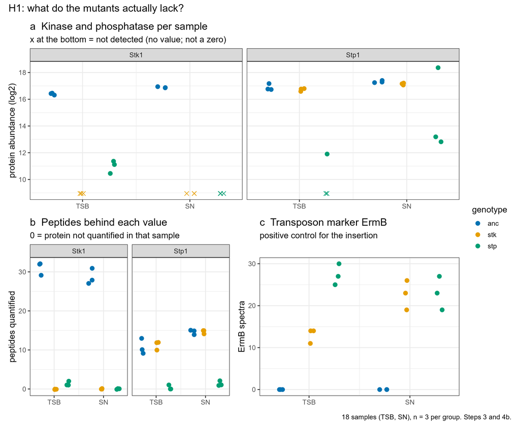

Step 3 evidence table (detections TSB/SNpulse/SN of 3 each; supplied lm_impute estimates are presence/absence evidence where lod_imputed).

| short_name | genotype | detections_TSB_SNpulse_SN | samples_2plus_peptides | supplied_diff_TSB_SNpulse_SN | any_lod_imputed | call |
| --- | --- | --- | --- | --- | --- | --- |
| Stk1 | stk | 0/1/0 | 0/0/0 | -2.34 / -1.66 / -2.83 | TRUE | supported reduction |
| Stk1 | stp | 3/2/0 | 1/1/0 | -2.34 / -2.01 / -2.83 | TRUE | supported reduction |
| Stp1 | stk | 3/3/3 | 3/3/3 | -0.17 / -0.4 / -0.17 | FALSE | no reduction |
| Stp1 | stp | 1/3/3 | 0/1/1 | -4.98 / -3.07 / -1.63 | FALSE | supported reduction |

- **Stk1:** not detected in `stk` in TSB or SN (0/6). In `stp` it is ~43-fold lower in TSB (estimate above) and resting on 1–2 peptides (29–32 in `anc`), and not detected in SN. The site T164 of Stk1 falls with the protein (Step 9).
- **Stp1:** 0–2 peptides in `stp` vs 9–15 in `anc`. The abundance values that remain are erratic, so the **size** of the loss cannot be estimated. Stp1 is unchanged in `stk`.
- **Insertion control:** ErmB (transposon marker) in 18/18 mutant samples, 0/9 `anc` (Step 4b, separate FragPipe search incl. transposon proteins).
- Neighbours of *stp1/stk1* are unchanged (Step 4). The pattern fits a polar insertion; protein data cannot exclude reduced stability, regulation or a secondary mutation.

# 5. H2: altered responses to PASN

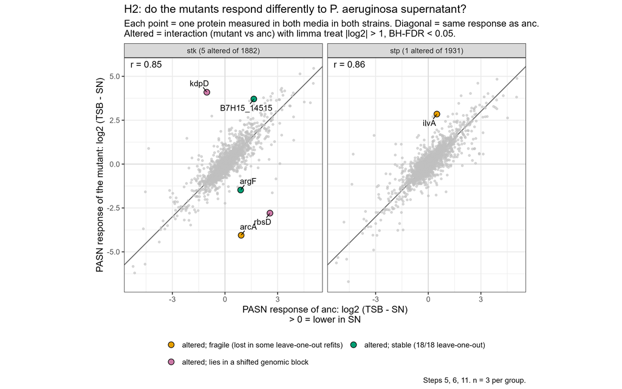

All formal interaction hits (Step 6/7) with their Step 11 stability. First strain = the mutant named first in the contrast.

| contrast | protein | diff | FDR | in words | leave-one-out | in shifted genomic block |
| --- | --- | --- | --- | --- | --- | --- |
| interaction_stk_vs_anc_at_TSB_vs_SN | rbsD | -5.36 | 1.1e-02 | SN response higher in first strain | 14/18 | TRUE |
| interaction_stk_vs_anc_at_TSB_vs_SN | kdpD | 5.13 | 0.0e+00 | SN response lower in first strain | 14/18 | TRUE |
| interaction_stk_vs_anc_at_TSB_vs_SN | arcA | -4.98 | 2.9e-03 | SN response higher in first strain | 16/18 | FALSE |
| interaction_stk_vs_anc_at_TSB_vs_SN | B7H15_14515 | 2.07 | 2.3e-03 | SN response lower in first strain | 18/18 | FALSE |
| interaction_stk_vs_anc_at_TSB_vs_SN | argF | -2.37 | 9.7e-05 | SN response higher in first strain | 18/18 | FALSE |
| interaction_stp_vs_anc_at_TSB_vs_SN | ilvA | 2.36 | 3.9e-02 | SN response lower in first strain | 9/18 | FALSE |
| interaction_stp_vs_stk_at_TSB_vs_SN | argF | 1.88 | 1.8e-02 | SN response lower in first strain | 14/18 | FALSE |
| interaction_stp_vs_stk_at_TSB_vs_SN | arcA | 5.36 | 2.8e-03 | SN response lower in first strain | 14/18 | FALSE |
| interaction_stp_vs_stk_at_TSB_vs_SN | B7H15_06000 | -2.67 | 2.8e-03 | SN response higher in first strain | 18/18 | FALSE |
| interaction_stp_vs_stk_at_TSB_vs_SN | lipA | 3.33 | 8.1e-06 | SN response lower in first strain | 18/18 | FALSE |

Both mutants keep most of the PASN response (r = 0.85 `stk`, 0.86 `stp` against `anc`). Only 5 of 1,882 (`stk`) and 1 of 1,931 (`stp`) tested proteins change their response. Raw values (Step 6) show that argF and B7H15_14515 are mainly a TSB baseline difference in `stk`, arcA and kdpD differ in both media, and only rbsD is mainly an SN difference. The single `stp` hit, ilvA, is fragile (9/18 refits) and probably shared with `stk` (one `stk_SN` replicate only). A lower threshold (1.5-fold) triples the lists but keeps the shape: `stk` 15 vs `stp` 5 (Step 11).

# 6. H3: does stp look like stk?

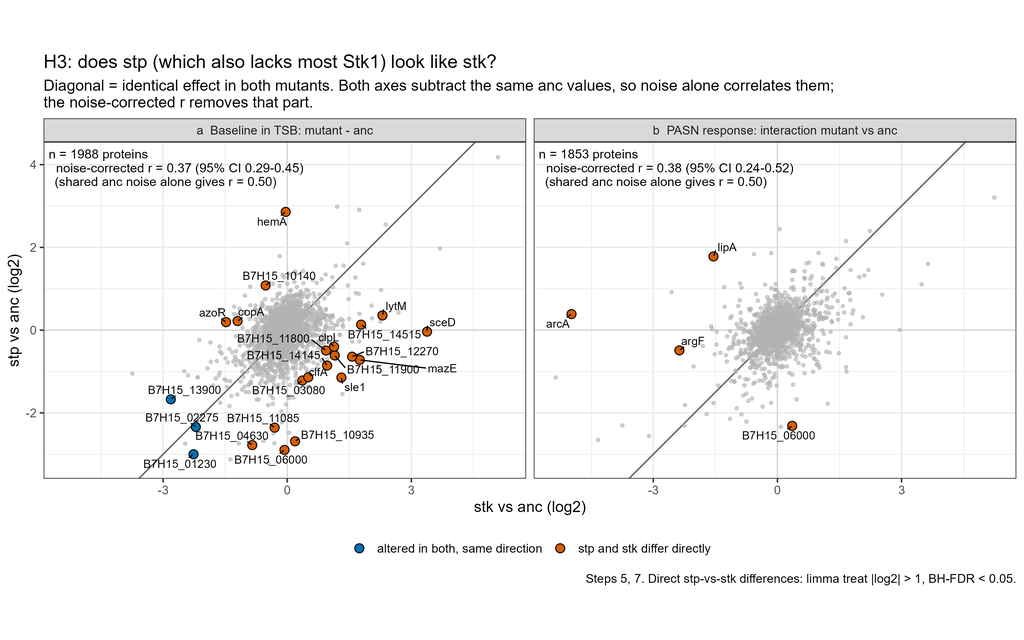

Similarity of the stp and stk effects (Step 7).

| layer | proteins | observed r | noise-only r | noise-corrected r | 95% CI | split-reference r (lower bound) |
| --- | --- | --- | --- | --- | --- | --- |
| baseline (TSB) | 1988 | 0.41 | 0.5 | 0.37 | 0.29-0.45 | 0.11-0.33 |
| response (TSB vs SN interaction) | 1853 | 0.43 | 0.5 | 0.38 | 0.24-0.52 | 0.03-0.15 |

Both axes subtract the same `anc` means, so noise alone gives r ≈ 0.50. After removing that part, the true effects correlate moderately (0.37–0.38): clearly above 0, far below 1. Only 3 proteins are hits in both mutants (same direction). 20 (TSB) + 4 (response) proteins differ directly; 6 of the 20 lie in genomic blocks that shift as a unit (section 8). At pathway level `stp` shares the peptidoglycan-synthesis and cytolysis shifts of `stk`, not the SigB/*mazEF* or ATP-synthase shifts (Step 10).

# 7. Phosphorylation (supporting layer)

Step 8 (STY search): sites usable per contrast and site hits (treat lfc = 1, our BH-FDR < 0.05). Supplied screen for comparison only.

| contrast | supported_sites | our_hits_up | our_hits_down | supplied_screen_hits_all_sites |
| --- | --- | --- | --- | --- |
| stk_vs_anc_at_TSB | 118 | 0 | 1 | 40 |
| stp_vs_anc_at_TSB | 155 | 1 | 2 | 39 |
| stp_vs_stk_at_TSB | 114 | 2 | 0 | 64 |
| TSB_vs_SN_at_anc | 184 | 2 | 8 | 170 |
| TSB_vs_SN_at_stk | 124 | 11 | 15 | 151 |
| TSB_vs_SN_at_stp | 148 | 11 | 8 | 147 |
| interaction_stk_vs_anc_at_TSB_vs_SN | 100 | 0 | 0 | 16 |
| interaction_stp_vs_anc_at_TSB_vs_SN | 125 | 0 | 0 | 33 |
| interaction_stp_vs_stk_at_TSB_vs_SN | 91 | 0 | 1 | 51 |

Only 91–184 of 3,774 sites per contrast are measured often and localised well enough; none responds differently to PASN in a mutant. Of 62 site hits (mostly TSB vs SN), 17 follow their protein, 40 change more than their protein (Step 9; the adjusted effect is descriptive, assuming independent layers). Genotype examples: deoB T85 lower in `stk` (TSB, protein unchanged), pyk T537 higher in `stp`, Stk1 T164 lower in `stp` with the protein.

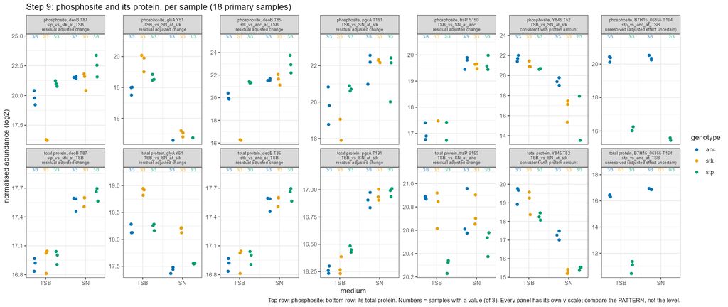

Figure 1

# 8. Pathway level and genome position

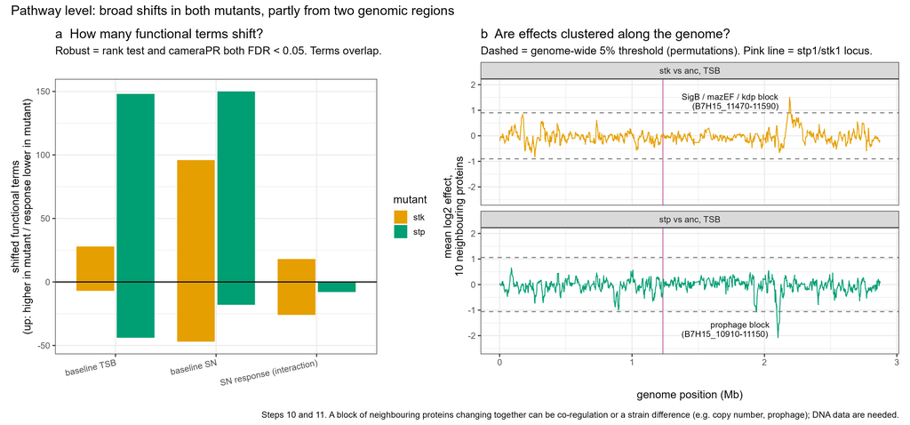

Most extreme 10-protein window per contrast (Step 11; threshold = genome-wide 5 %, 1000 permutations).

| contrast | first_tag | last_tag | start | window_mean | threshold | p_familywise |
| --- | --- | --- | --- | --- | --- | --- |
| interaction_stk_vs_anc_at_TSB_vs_SN | B7H15_11010 | B7H15_11115 | 2112715 | -1.181 | 1.044 | 0.011 |
| interaction_stp_vs_anc_at_TSB_vs_SN | B7H15_10925 | B7H15_11110 | 2103129 | -1.328 | 0.930 | < 0.001 |
| stk_vs_anc_at_SN | B7H15_01460 | B7H15_01545 | 315665 | 1.093 | 1.054 | 0.039 |
| stk_vs_anc_at_TSB | B7H15_11500 | B7H15_11550 | 2189711 | 1.510 | 0.901 | < 0.001 |
| stp_vs_anc_at_SN | B7H15_07835 | B7H15_08155 | 1555995 | -1.096 | 0.953 | 0.006 |
| stp_vs_anc_at_TSB | B7H15_10925 | B7H15_11110 | 2103129 | -2.079 | 1.060 | < 0.001 |

Many functional terms shift in both mutants, `stp` as many as `stk` in TSB and SN; `stk` has more only in the response. “Stk1 broadly involved” is therefore **not** specific to the kinase mutant. Two genomic blocks change as a unit:

- **`stk`, B7H15_11470–11590** (SigB operon, *mazEF*, *alr1*, *acpS*, *kdpCBA/DE*, *murF*, *ddl*): +1.5 log2, the top window in the genome. Unrelated neighbours rising ~2-fold together fit a copy-number change in this strain; regional regulation is the alternative.
- **`stp`, B7H15_10910–11150, a prophage:** −2.1 log2 in TSB; it also drives the most extreme windows of both interaction contrasts.

# 9. Answers, limitations and follow-up

|  | answer | status (Step 11) |
| --- | --- | --- |
| **H1** | `stp` lacks most Stk1 (~43-fold) as well as Stp1; `stk` lacks Stk1 | **supported**; polar mechanism consistent, not proven |
| **H2** | Few altered PASN responses (5 `stk`, 1 `stp`); the response is largely intact | **supported, small**; 2 `stk` hits fully robust, `stp` hit fragile |
| **H3** | A moderate shared component (r ≈ 0.37) plus clear differences | **partly supported (tentative)** |

**Limitations.** n = 3 (non-significance is weak evidence of no effect); no clean deletions or complemented strains; the `stp` strain is a phosphatase mutant with strongly reduced kinase, not a phosphatase-only mutant; phosphosite coverage is sparse; two genomic blocks may reflect strain differences; PASN mixes secreted molecules and nutrient depletion; total-proteome run order was blocked by group (drift cannot be separated from group).

**Follow-up proposal (future experiments).** (1) Sequence the three strains or run qPCR on the *stk* block (B7H15_11465–11700) and the prophage region. (2) Measure *stp1*/*stk1* transcripts in `stp` to test polarity. (3) Compare clean Δ*stp1* (keeping Stk1), Δ*stk1* and a verified double deletion with complemented strains under PASN.

# 10. References, software and AI use

- Olsen JV et al. (2006) *Cell* 127:635–48. [doi:10.1016/j.cell.2006.09.026](https://doi.org/10.1016/j.cell.2006.09.026)
- McCarthy DJ, Smyth GK (2009) *Bioinformatics* 25:765–71. [doi:10.1093/bioinformatics/btp053](https://doi.org/10.1093/bioinformatics/btp053)
- Wu D, Smyth GK (2012) *Nucleic Acids Res* 40:e133. [doi:10.1093/nar/gks461](https://doi.org/10.1093/nar/gks461)
- Ritchie ME et al. (2015) *Nucleic Acids Res* 43:e47. [doi:10.1093/nar/gkv007](https://doi.org/10.1093/nar/gkv007)
- Stk1/Stp1 background (checked 5 Nov, see evidence review): Sun et al. 2012 *PNAS* [doi:10.1073/pnas.1205952109](https://doi.org/10.1073/pnas.1205952109); Burnside et al. 2010 *PLOS ONE* [doi:10.1371/journal.pone.0011071](https://doi.org/10.1371/journal.pone.0011071); Beltramini et al. 2009 *Infect Immun* [doi:10.1128/IAI.01499-08](https://doi.org/10.1128/IAI.01499-08); Huemer et al. 2023 *Sci Signal* [doi:10.1126/scisignal.abj8194](https://doi.org/10.1126/scisignal.abj8194).
- Genome: *S. aureus* JE2, GenBank CP020619.1. Protein names: `read_protein_metadata()` (UniProt orthologs, `ortholog_quality == "good"`).

**AI use.** Claude Code (Anthropic) wrote and ran the analysis scripts under the group’s rules, proposed the Step 8–11 rules (marked “group to confirm” in the figure guides), found and fixed errors (documented in the lab notebook), and drafted this report. The group still has to check every number and claim before submission.